# Processo di miscelazione in continuo

Per una linea di produzione occorre dimensionare un reattore per la miscelazione.  
Il processo consiste nella miscelazione di due stream uno composto dall'ingrediente d'interessa $A$ ed un altro composto dal fluido per generare la sospensione $S$.  
La concentrazione nello stream in ingresso vale $c_{A,f}=200 g/L$.  
I requisiti per il sistema sono i seguenti:

- La concentrazione del prodotto finale deve appartenere all'intervallo 7.8 - 8.2 g/L.
- In ogni istante nel sistema il tempo di residenza nel reattore deve appartenere al range tra le 84 e le 108 ore.
- Il limite massimo per il volume del reattore è 15000 L, mentre quello minimo vale 8000 L.

# Modellazione del sistema

## Bilanci di materia

### Bilancio totale di materia

$$\frac{dV}{dt}=q_A+q_s-q_{out}$$

### Bilancio di materia per la specie A

$$\frac{d(Vc_A)}{dt}=q_A c_{A,f}-q_{out}c_A$$

Nel bilancio di materia possono essere applicate le ipotesi di perfetta miscelazione e di densità costante. $$\frac{dV}{dt}=q_A+q_s-q_{out}$$ $$c_A\frac{d(V)}{dt}+V\frac{d(c_A)}{dt}=q_A c_{A,f}-q_{out}c_A$$ Posso sostituire il bilancio totale di materia in quello per la specie A. $$\frac{dV}{dt}=q_A+q_s-q_{out}$$ $$c_A(q_A+q_s-q_{out})+\frac{d(c_A)}{dt}=q_A c_{A,f}-q_{out}c_A$$ Dividendo entrambi i termini del bilnacio di materia per la specie A si ottiene: $$\frac{dc_A}{dt}=\frac{q_A}{V}(c_{A,f}-c_A)-\frac{q_s}{V}c_A$$

## Introduzione variabili nel sistema

#### Parametri

```matlab
Vmax = 15000;                              %Volume massimo del reattore [L]
Vmin = 8000;                               %Volume minimo del reattore [L]
cAf = 200;                                 %Concentrazione in ingresso [g/L]
rtime = 96;                                %Tempo di residenza [h]
caProd = 8;                                %Concentrazione in uscita [g/L]
qout_bar = 125;                            %Portata in uscita(Dipende dalla domanda a valle del sistema modellato)[Variabile modificabile]
```

### Definizione delle condizioni in stato stazionario

Il volume allo stato stazionario può essere calcolato utilizzando il valore del tempo di residenza medio per la portata in uscita dal reattore.

```matlab
V_bar = rtime * qout_bar;                      %Volume del reattore in SS [L]
ca_bar = caProd;                           %Concentrazione in uscita [g/L]
qa_bar = caProd * qout_bar / cAf;              %Portata in Entrata [L/h]
qs_bar = qout_bar - qa_bar;                    %Portata di fluido per sospensione [L/h]

%Stampa dei valori allo Stato Stazionario(SS)
disp('Stato stazionario')
StrVol = sprintf('Volume[L] = %1.0f',V_bar);
StrConc = sprintf('Concentrazione in Uscita[L] = %1.0f',ca_bar);
StrA = sprintf('POrtata in Ingresso A[L/h] = %1.0f',qa_bar);
StrS = sprintf('Portata in Ingresso S[L/h] = %1.0f',qs_bar);
disp(StrVol)
disp(StrConc)
disp(StrA)
disp(StrS)
```

```
Stato stazionario
Volume[L] = 12000
Concentrazione in Uscita[L] = 8
POrtata in Ingresso A[L/h] = 5
Portata in Ingresso S[L/h] = 120
```

### Definizione delle condizioni in stato non stazionario

Per risolvere il sistema in stato non stazionario occorre ricorrere alla risoluzione del ODE utilizzando un risolutore, ad esempio ode15s.  
Per poter utilizzare il risolutore è necessario definire una funzione, questa verra inserita in un file .m allegato, con il codice riportato di seguito.

function [func] = MBs(t,x0,qa,qs,qout,cA_bar) V = x0(1); cA = x0(2); dVdt = qa + qs - qout; dcadt = qa*(cA_bar - cA)/V - qs *cA / V; func = [dVdt dcadt]'; end

```matlab
tspan = linspace(0,200,200);                          %Vettore tempi per valutare il sistema di equazioni differenziali [h]

%Gradi di liberta fissi
qa = qa_bar;
qs = qs_bar;

%Condizioni iniziali del sistema
t=0;
V = V_bar;
ca = ca_bar;

%Vettore condizioni iniziali
x0 = [V, ca];

options = odeset("RelTol",1e-6);
[t sol] = ode15s(@MBs,tspan,x0,options,qa,qs,qout_bar,cAf);
```

#### Grafici

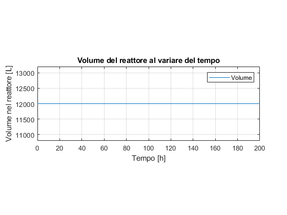

```matlab
plot(t,sol(:,1)), grid on
xlabel('Tempo [h]')
ylabel('Volume nel reattore [L]')
title('Volume del reattore al variare del tempo')
legend('Volume')
ax = gca; % axes handle
ax.YAxis.Exponent = 0;
axis([0, max(t), min(sol(:,1))*0.9, max(sol(:,1))*1.1])
pbaspect([3 1 1])
```

Possiamo notare come il valore del volume nel reattore al variare del tempo rimanga costante in condizioni di SS.

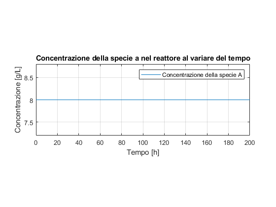

```matlab
plot(t,sol(:,2)), grid on
xlabel('Tempo [h]')
ylabel('Concentrazione [g/L]')
title('Concentrazione della specie a nel reattore al variare del tempo')
legend('Concentrazione della specie A')
ax = gca; % axes handle
ax.YAxis.Exponent = 0;
axis([0, max(t), min(sol(:,2))*0.9, max(sol(:,2))*1.1])
pbaspect([3 1 1])
```

Anche il valore della concentrazione all'interno del sistema rimane costante allo SS.

### Comportamento dinamico del reattore al variare delle condizioni

```matlab
ca = 0;
%Vettore condizioni iniziali
x0 = [V, ca];

options = odeset("RelTol",1e-6);
[t1 sol1] = ode15s(@MBs,tspan,x0,options,qa,qs,qout_bar,cAf);
```

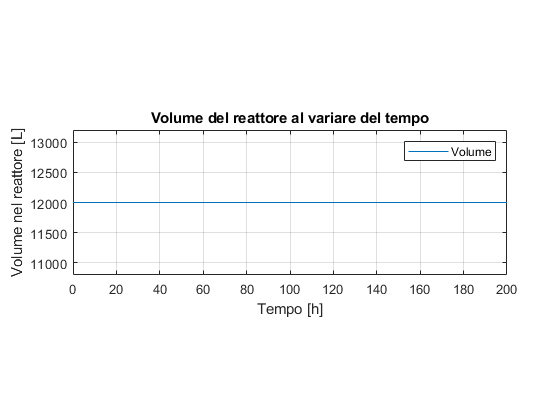

```matlab
plot(t1,sol1(:,1)), grid on
xlabel('Tempo [h]')
ylabel('Volume nel reattore [L]')
title('Volume del reattore al variare del tempo')
legend('Volume')
ax = gca; % axes handle
ax.YAxis.Exponent = 0;
axis([0, max(t1), min(sol1(:,1))*0.9, max(sol1(:,1))*1.1])
pbaspect([3 1 1])
```

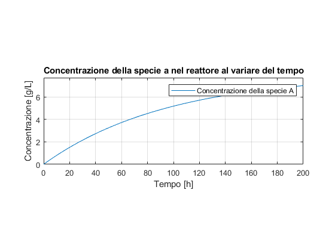

```matlab
plot(t1,sol1(:,2)), grid on
xlabel('Tempo [h]')
ylabel('Concentrazione [g/L]')
title('Concentrazione della specie a nel reattore al variare del tempo')
legend('Concentrazione della specie A')
ax = gca; % axes handle
ax.YAxis.Exponent = 0;
axis([0, max(t1), min(sol1(:,2))*0.9, max(sol1(:,2))*1.1])
pbaspect([3 1 1])
```

```matlab
tspan = linspace(0,500,500);                          %Vettore tempi per valutare il sistema di equazioni differenziali [h]
qout_bar = 125;
qout = 0.9*qout_bar;

%Valore di K
K = 5;

%Gradi di liberta fissi
qa = qa_bar;

%Condizioni iniziali del sistema
V = V_bar;
ca = ca_bar;

%Vettore condizioni iniziali
x0 = [V, ca];

options = odeset("RelTol",1e-6);
[t2 sol2] = ode15s(@MBsqsvariabile,tspan,x0,options,qa,qs_bar,qout,qout_bar,cAf,K,V_bar);
```

Per risolvere il seguente problema occorre andare a definire il valore di $q_S$ all'interno della function matlab che viene utilizzata per risolvere l'odes, MBsqsvariabile.m .

function [func] = MBsqsvariabile(t,x0,qa,qsbar,qout,qoutbar,cAf,K,Vbar) V = x0(1); cA = x0(2); qs = qsbar - K* ( V/qout - Vbar/qoutbar); dVdt = qa + qs - qout; dcadt = qa*(cAf - cA)/V - qs *cA / V; func = [dVdt dcadt qs]'; end

```matlab
for i=1:1:length(sol2)
Vsuq(i) = MBsqsvariabileVsuq(t2(i),sol2(i,:),qout);
qs(i) = MBsqsvariabileqs(t2(i),sol2(i,:),qs_bar,qout,qout_bar,K,V_bar);
end
```

Per poter ottenere i valori delle variabili Vsuq e qs al variare del tempo t occorre valutarle utilizzando due funzioni Matlab dedicate: file MBsqsvariabileVsuq.m function [Vsuqout] = MBsqsvariabileVsuq(t,x0,qa,qsbar,qout,qoutbar,cAf,K,Vbar) V = x0(1); cA = x0(2); Vsuqout = V/qout; end file MBsqsvariabileqs.m function [qs] = MBsqsvariabileqs(t,x0,qa,qsbar,qout,qoutbar,cAf,K,Vbar) V = x0(1); cA = x0(2); qs = qsbar - K* ( V/qout - Vbar/qoutbar); end

#### Grafici

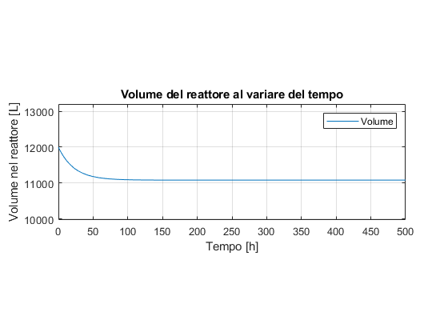

```matlab
figure(1)
plot(t2,sol2(:,1)), grid on
xlabel('Tempo [h]')
ylabel('Volume nel reattore [L]')
title('Volume del reattore al variare del tempo')
legend('Volume')
ax = gca; % axes handle
ax.YAxis.Exponent = 0;
axis([0, max(t2), min(sol2(:,1))*0.9, max(sol2(:,1))*1.1])
pbaspect([3 1 1])
```

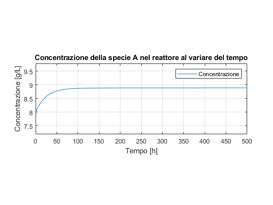

```matlab
figure(2)
plot(t2,sol2(:,2)), grid on
xlabel('Tempo [h]')
ylabel('Concentrazione [g/L]')
title('Concentrazione della specie A nel reattore al variare del tempo')
legend('Concentrazione')
ax = gca; % axes handle
ax.YAxis.Exponent = 0;
axis([0, max(t2), min(sol2(:,2))*0.9, max(sol2(:,2))*1.1])
pbaspect([3 1 1])
```

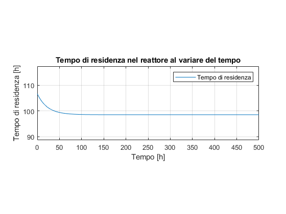

```matlab
figure(3)
plot(t2,Vsuq), grid on
xlabel('Tempo [h]')
ylabel('Tempo di residenza [h]')
title('Tempo di residenza nel reattore al variare del tempo')
legend('Tempo di residenza')
ax = gca; % axes handle
ax.YAxis.Exponent = 0;
axis([0, max(t2), min(Vsuq)*0.9, max(Vsuq)*1.1])
pbaspect([3 1 1])
```

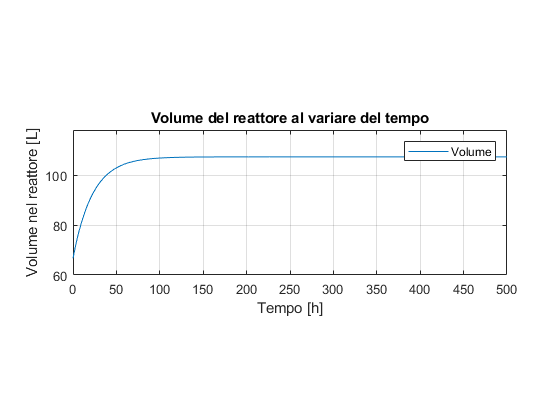

```matlab
figure(4)
plot(t2,qs), grid on
xlabel('Tempo [h]')
ylabel('Volume nel reattore [L]')
title('Volume del reattore al variare del tempo')
legend('Volume')
ax = gca; % axes handle
ax.YAxis.Exponent = 0;
axis([0, max(t2), min(qs)*0.9, max(qs)*1.1])
pbaspect([3 1 1])
```

### Controllo con feedback utilizzando la concentrazione della specie per controllare il flusso della stessa specie in ingresso

Come per quanto appena discusso per la portata in uscita è possibile applicare un controllo alla concentrazione all'interno del miscelatore in modo da poterla regolare.
Per il controllo con feedback in esame verrà utilizzata la concentrazione della specie all'interno del reattore per modificare il valore della portata della corrente contenente la medesima specie in ingresso mediante una valvola posta a monte rispetto al reattore.
Il metodo per la generazioe del controllo è simile a quello applicato in precedenza e si presenta dopo la opportune rielaborazioni come: $$\begin{equation} q_A=\overline{q_A}-K(c_A - \overline{c_A}) \end{equation}$$ Il significato di questa formula è che è previsto un decremento della portata in ingresso in caso di superamento del valore di concentrazione ottimale all'interno del reattore.

```matlab
tspan = linspace(0,500,500);                          %Vettore tempi per valutare il sistema di equazioni differenziali [h]
qout_bar = 125;
qout = 0.9*qout_bar;

%Valore di K
K1 = 5;
K2 = 3;

%Gradi di liberta fissi
qa = qa_bar;

%Condizioni iniziali del sistema
V = V_bar;
ca = ca_bar;

%Vettore condizioni iniziali
x0 = [V, ca];

options = odeset("RelTol",1e-6);
[t3 sol3] = ode15s(@MBsqsqavariabile,tspan,x0,options,qa_bar,qs_bar,qout,qout_bar,cAf,ca_bar,K1,K2,V_bar);
```

function [func] = MBsqsqavariabile(t,x0,qabar,qsbar,qout,qoutbar,cAf,cAbar,K1,K2,Vbar) V = x0(1); cA = x0(2); qs = qsbar - K1* ( V/qout - Vbar/qoutbar); qa = qabar - K2* ( cA - cAbar); dVdt = qa + qs - qout; dcadt = qa*(cAf - cA)/V - qs *cA / V; func = [dVdt dcadt]'; end

```matlab
for i=1:1:length(sol3)
Vsuq3(i) = MBsqsvariabileVsuq(t3(i),sol3(i,:),qout);
qs3(i) = MBsqsvariabileqs(t3(i),sol3(i,:),qs_bar,qout,qout_bar,K1,V_bar);
qa3(i) = MBsqsvariabileqa(t3(i),sol3(i,:),qa_bar,ca_bar,K2);
end
```

#### Grafici

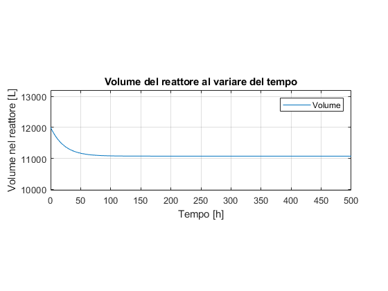

```matlab
figure(1)
plot(t3,sol3(:,1)), grid on
xlabel('Tempo [h]')
ylabel('Volume nel reattore [L]')
title('Volume del reattore al variare del tempo')
legend('Volume')
ax = gca; % axes handle
ax.YAxis.Exponent = 0;
axis([0, max(t3), min(sol3(:,1))*0.9, max(sol3(:,1))*1.1])
pbaspect([3 1 1])
```

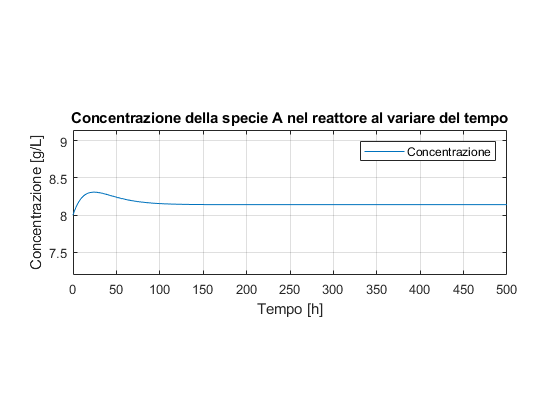

```matlab
figure(2)
plot(t3,sol3(:,2)), grid on
xlabel('Tempo [h]')
ylabel('Concentrazione [g/L]')
title('Concentrazione della specie A nel reattore al variare del tempo')
legend('Concentrazione')
ax = gca; % axes handle
ax.YAxis.Exponent = 0;
axis([0, max(t3), min(sol3(:,2))*0.9, max(sol3(:,2))*1.1])
pbaspect([3 1 1])
```

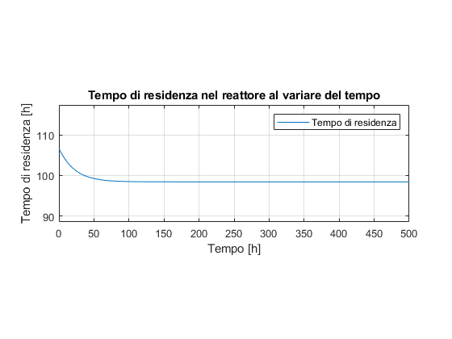

```matlab
figure(3)
plot(t2,Vsuq3), grid on
xlabel('Tempo [h]')
ylabel('Tempo di residenza [h]')
title('Tempo di residenza nel reattore al variare del tempo')
legend('Tempo di residenza')
ax = gca; % axes handle
ax.YAxis.Exponent = 0;
axis([0, max(t2), min(Vsuq3)*0.9, max(Vsuq3)*1.1])
pbaspect([3 1 1])
```

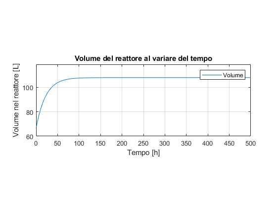

```matlab
figure(4)
plot(t2,qs3), grid on
xlabel('Tempo [h]')
ylabel('Volume nel reattore [L]')
title('Volume del reattore al variare del tempo')
legend('Volume')
ax = gca; % axes handle
ax.YAxis.Exponent = 0;
axis([0, max(t2), min(qs3)*0.9, max(qs3)*1.1])
pbaspect([3 1 1])
```

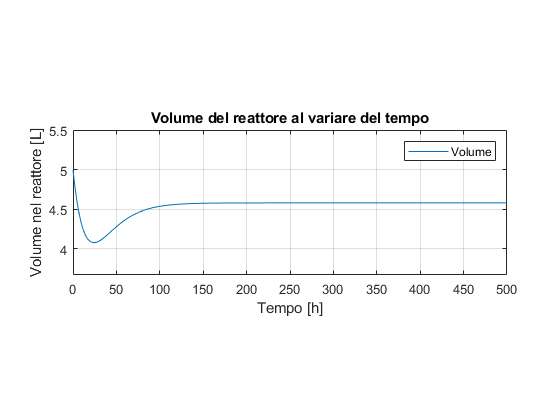

```matlab
figure(5)
plot(t3,qa3), grid on
xlabel('Tempo [h]')
ylabel('Volume nel reattore [L]')
title('Volume del reattore al variare del tempo')
legend('Volume')
ax = gca; % axes handle
ax.YAxis.Exponent = 0;
axis([0, max(t2), min(qa3)*0.9, max(qa3)*1.1])
pbaspect([3 1 1])
```

### Controllo Proporzionale-Integrativo

Dopo aver definito due tipologie di controllo proporzionale per la portata in uscita e per quella di miscela A in ingresso è necessario andare a valutare una metodologia di approccio che data una variazione nelle condizioni di utilizzo possa riportare il sistema da uno stato stazionario definito in precedenza, per fare ciò viene introdotta una nuova tipologia di controllo quello Integrativo.
L'effetto dell'azione integrale è quello di far sì che il controllore abbia memoria dei valori passati del segnale d'errore, in particolare, il valore dell'azione integrale non è necessariamente nullo se è nullo il segnale d'errore. $$q_A = \overline{q}_A - K_P(c_A -\overline{c}_A)-K_i\int_{0}^{t}(c_A - \overline{c}_A)dt$$

```matlab
clc
clear all
close all
format long

Vmax = 15000;                              %Volume massimo del reattore [L]
Vmin = 8000;                               %Volume minimo del reattore [L]
cAf = 200;                                 %Concentrazione in ingresso [g/L]
rtime = 96;                                %Tempo di residenza [h]
caProd = 8;                                %Concentrazione in uscita [g/L]
qout_bar = 125;                            %Portata in uscita(Dipende dalla domanda a valle del sistema modellato)[Variabile modificabile]

V_bar = rtime * qout_bar;                      %Volume del reattore in SS [L]
ca_bar = caProd;                           %Concentrazione in uscita [g/L]
qa_bar = caProd * qout_bar / cAf;              %Portata in Entrata [L/h]
qs_bar = qout_bar - qa_bar;

tstamp = 1:1:500;                       %Vettore tempi per valutare il sistema di equazioni differenziali [h]
qout_bar = 125;
qout = 0.9*qout_bar;

global error_sum error;
error = 0;
error_sum = 0;

%Valore di K
t  = 0;
dt = 1;
K1 = 5;
K2 = 3;
Ki = 0.4;

%Gradi di liberta fissi
qa = qa_bar;

%Condizioni iniziali del sistema
V = V_bar;
ca = ca_bar;

%Vettore condizioni iniziali
x0 = [V, ca];

storico = [];

while t < 500

    qs = qs_bar - 5*(V/qout - V_bar/qout_bar);

    error = (ca - ca_bar);
    error_sum = error_sum + error * dt;

    qa = qa_bar - 3*error - 0.4*error_sum;
    tfin = t + dt;
    tspan = [t tfin];
    options = odeset('RelTol',1e-6);
    [tempi, sol] = ode15s(@MBsqsqavariabileint,tspan,x0,options,qa,qs,qout,cAf);
    x0 = [sol(length(sol),1),  sol(length(sol),2)];
    ca = sol(length(sol),2);
    V = sol(length(sol),1);

t = t + dt;
storico(:,t) = [t, sol(length(sol),1), sol(length(sol),2), V/qout, qs, qa];
end
```

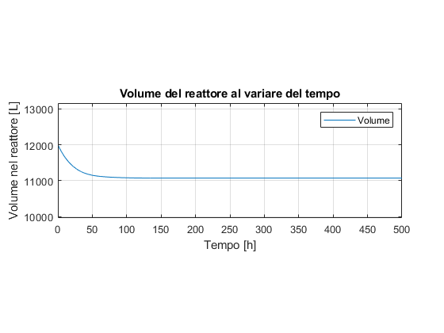

```matlab
figure(1)
plot(tstamp,storico(2,:)), grid on
xlabel('Tempo [h]')
ylabel('Volume nel reattore [L]')
title('Volume del reattore al variare del tempo')
legend('Volume')
ax = gca; % axes handle
ax.YAxis.Exponent = 0;
axis([0, max(tstamp), min(storico(2,:))*0.9, max(storico(2,:))*1.1])
pbaspect([3 1 1])
```

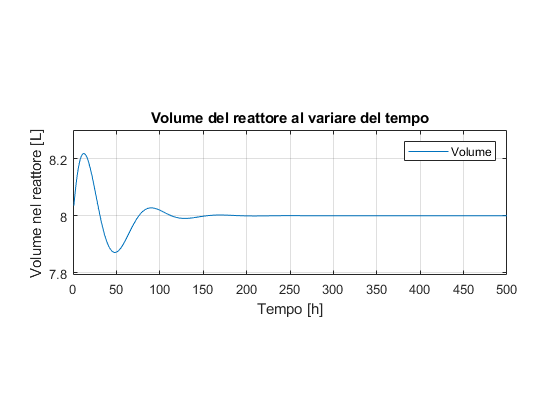

```matlab
figure(2)
plot(tstamp,storico(3,:)), grid on
xlabel('Tempo [h]')
ylabel('Volume nel reattore [L]')
title('Volume del reattore al variare del tempo')
legend('Volume')
ax = gca; % axes handle
ax.YAxis.Exponent = 0;
axis([0, max(tstamp), min(storico(3,:))*0.99, max(storico(3,:))*1.01])
pbaspect([3 1 1])
```

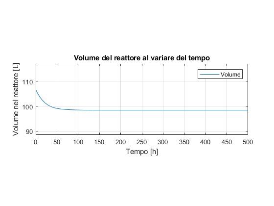

```matlab
figure(3)
plot(tstamp,storico(4,:)), grid on
xlabel('Tempo [h]')
ylabel('Volume nel reattore [L]')
title('Volume del reattore al variare del tempo')
legend('Volume')
ax = gca; % axes handle
ax.YAxis.Exponent = 0;
axis([0, max(tstamp), min(storico(4,:))*0.9, max(storico(4,:))*1.1])
pbaspect([3 1 1])
```

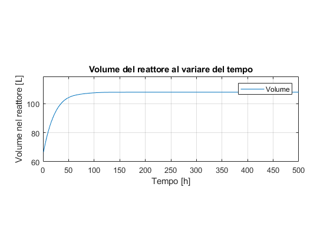

```matlab
figure(4)
plot(tstamp,storico(5,:)), grid on
xlabel('Tempo [h]')
ylabel('Volume nel reattore [L]')
title('Volume del reattore al variare del tempo')
legend('Volume')
ax = gca; % axes handle
ax.YAxis.Exponent = 0;
axis([0, max(tstamp), min(storico(5,:))*0.9, max(storico(5,:))*1.1])
pbaspect([3 1 1])
```

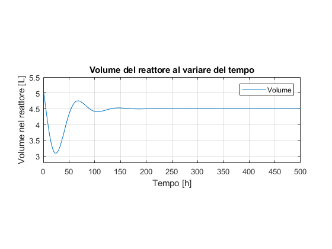

```matlab
figure(5)
plot(tstamp,storico(6,:)), grid on
xlabel('Tempo [h]')
ylabel('Volume nel reattore [L]')
title('Volume del reattore al variare del tempo')
legend('Volume')
ax = gca; % axes handle
ax.YAxis.Exponent = 0;
axis([0, max(tstamp), min(storico(6,:))*0.9, max(storico(6,:))*1.1])
pbaspect([3 1 1])
```